# PEC2 Análisis de Datos Ómicos

Francisco Abel Cedrón Santaeufemia

11 de Junio de 2020

> **Repositorio:** https://github.com/fcedron-ouc/ADO_PEC2

> **NOTA:** Aunque en el enunciado de la PEC pone que no se abuse de las salidas de R, la razón por la que quizás he puesto más de las indicadas es porque después de la PEC1 he visto que se me ha penalizado por no añadirlo y he decidido incluir más contenido esta vez, ya que a día de hoy sigo sin comprender como se evalúan las PEC.

# Abstract

RNA-Seq es la técnica que se emplea actualmente para el análisis de los niveles de expresión génica. RNA-seq se basa en la secuenciación del ARNm para posteriormente mapearlo en secuencias de referencia. Esta PEC tiene como estudio el análisis de la tiroides, donde se comparan tres tipos de inflitraciones:

- NIT: Not inflitrated tissues
- SFI: Small focal inflitrates
- ELI: Extensive lymphoid inflitrates

# Objetivos

El objetivo de esta PEC se basa en realizar un proceso de análisis de datos de ultrasecuenciación mediante la realización de un estudio. Dicho estudio es el álisis de la inflamación de la tiroides a partir de 10 muestras aleatorias a partir de 3 tipos de datos diferentes. A partir de los datos seleccionados se llevarán a cabo una comparación con las tres combinaciones posibles, en búsqueda de los genes DE (diferencialmente expresados) y su análisis biológico. Además, se comprobará qué genes son destacables en las inflitraciones y si estos son responsables de las funciones tiroideas.

# Materiales y métodos

## Naturaleza de los datos

Los datos empleados en esta PEC han sido proporcionados a través de un mensaje en el tablón y se corresponden con las muestras de un estudio obtenido del repositorio GTEx el cual tiene datos de expresión RNA-seq de un análisis tiroideo. El repositorio cuenta con datos de tres tipos de infiltraciones diferentes:

- *Not inflitrated tissues (NIT): 236 samples*
- *Small focal infiltrates (SFI): 42 samples*
- *Extensive lymphoid inflitrates (ELI): 14 samples*

Los datos con los que se ha de trabajar vienen proporcionados en dos archivos *csv*:

- *counts.csv* que contiene los datos de expresión de RNA-seq de todas las muestras para el estudio
- *targets.csv* que contiene la información para cada una de las muestras donde entre otras características está el tipo de infiltración.

## Métodos y herramientas

De las dos herramientas que se podían realizar el trabajo se ha seleccionado el uso del lenguaje R (versión 3.6.3) con lo que apoya en CRAN y Bioconductor para los paquetes. Todo está corriendo en un RStudio Server (versión 1.3.959) que está emulado en un docker (versión 19.03.8) usando una base de macOS Catalina (versión 10.15.4). Para la realización del informe se ha empleado RMarkDown.

Para el análisis del RNA-seq, las librerías que se han empleado han sido las de Bioconductor por su facilidad al tratar con datos biológicos.

## Pasos seguidos

Los pasos que se han seguido para la elaboración de este estudio están basados en el pipeline proporcionados en el enunciado de la PEC.

### Preprocesado de los datos

#### Extracción de las muestras

El primer paso es la extracción de las muestras a partir de los datos que se encuentran en los archivos csv porporcionados.

```r
set.seed(CUSTOM_SEED)

counts = read.csv("data/counts.csv", header=T, sep=";")
target = read.csv("data/targets.csv", header=T, sep=",")

# hay que seleccionar las secciones adecuadas dentro de target
NIT <- subset(target, grepl("^(NIT)", target$Group))
SFI <- subset(target, grepl("^(SFI)", target$Group))
ELI <- subset(target, grepl("^(ELI)", target$Group))
```

Una vez están cargados los datos se seleccionan 10 muestras aleatorias de cada grupo y se extraen las secuencias correspondientes del fichero de counts.

```r
target_NIT_10 <- sample_n(NIT, 10)
target_SFI_10 <- sample_n(SFI, 10)
target_ELI_10 <- sample_n(ELI, 10)

nit <- counts[, target_NIT_10$Sample_Name]
sfi <- counts[, target_SFI_10$Sample_Name]
eli <- counts[, target_ELI_10$Sample_Name]

samples <- cbind(nit, sfi, eli)
rownames(samples) <- counts[, 1]
```

Al final se tienen 56202 expresiones de genes y las 30 columnas que se corresponden con las inflitraciones.

#### Limpieza de datos

Como buena práctica es recomendable examinar siempre si existen *NAs* para saber que hacer con ellos. Por suerte, en la muestra seleccionada no existen datos con nulos asi que no hay que preocuparse por ellos.

```r
table(is.na(samples))
```

```
  FALSE
1686060
```

También se analizan los *loci* que no tengan un cierto valor para el análisis, así que se eliminan loque tengan de media un 0 por su escasa significancia.

```r
mean_genes<-apply(samples, 1, mean)
# boxplot(mean_genes)
table(mean_genes == 0)
```

```
FALSE  TRUE
46302  9900
```

Se observa que hay 9900 *loci* con una media de cero lo que indica que no tienen apenas significancia para el análisis y que se pueden eliminar para evitar que existan alteraciones por el posible ruido que puedan causar. Después de este filtrado de datos se dispondrán de 46302 exprexiones de genes.

```r
tmp<-samples[which(mean_genes == 0), ]
i<-intersect(rownames(tmp), rownames(samples))
samples<-samples[!rownames(samples)%in% i, ]
# mean_genes_tmp<-apply(samples, 1, mean)
# barplot(mean_genes_tmp, main = "Barplot de expresión", xlim=NULL, xlab="Genes", ylab="Frecuencia")
```

#### Normalización

En la gráfica se puede ver que existen una serie de genes que están mucho más expresados que otros. Para poder observar los datos de una manera más clara se va a proceder a normalizarlos.

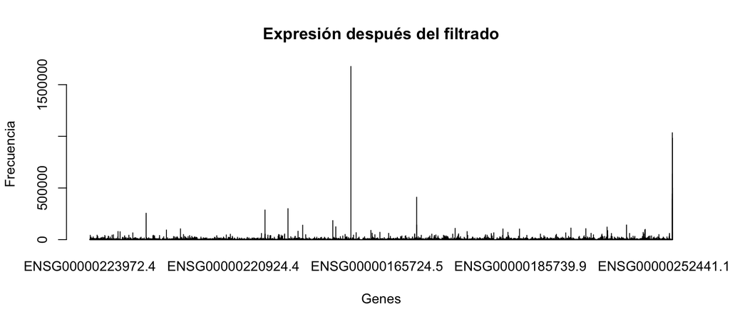

Para normalizarlos se emplea una técnica llamada *TMM* ya que es una normalización que está diseñada específicamente para producción de ARN e intenta conservar las propiedades de las muestras que se analizarán, lo que ayuda a la comparación de la expresión de genes.

```r
normalize_samples <- normalizeCounts(samples)
```

Con el uso de la función *maPlot* se observa que al normalizar los datos con la función *normalizeCounts* existe una variabilidad menor, lo que puede ayudar a realizar un mejor análisis.

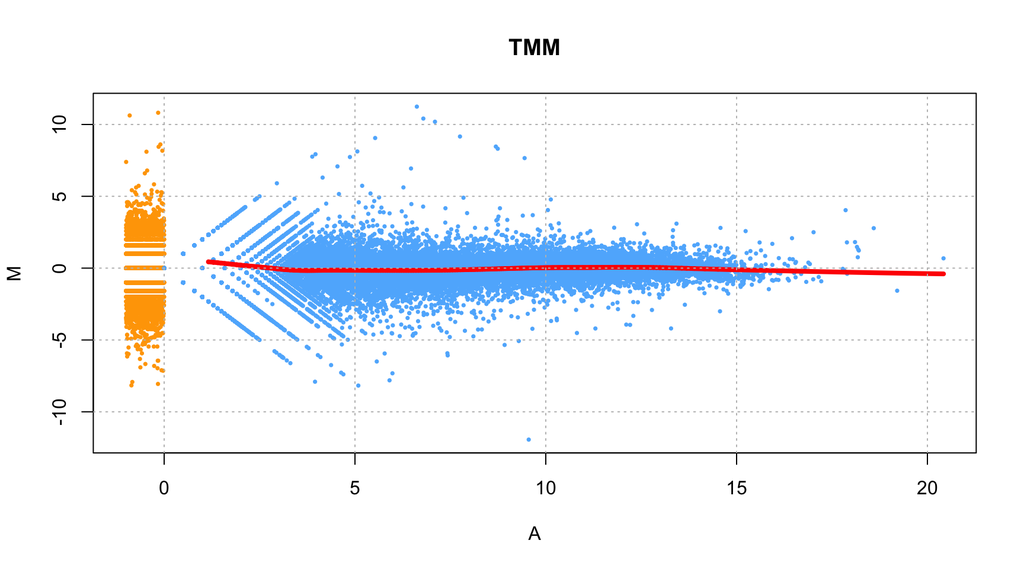

# Resultados y discusión

## Comparación NIT-SFI

El primer paso que se hace es el de crear un grupo con las infiltraciones de la comparación NIT y SFI seleccionando las muestras adecuadas del dataframe original. A continuación se aplica un refiltrado con la función *sweep*. El objetivo de hacer este refiltrado es que el gen tenga alguna presencia, para esto se va indicar que aparezca como mínimo 1 lectura por cada millón de veces que sea mapeado.

```r
comp_NIT_SFI <- normalize_samples[, 1:20]

col_NIT_SFI <- rbind(target_NIT_10, target_SFI_10)
group_NIT_SFI <- factor(col_NIT_SFI$Group)

d <- calcNormFactors(DGEList(counts = comp_NIT_SFI, group=group_NIT_SFI))
m <- sweep(d$counts, 2, 1e6 / d$samples$lib.size, "*")
ridx_NIT_SFI <- rowSums(m>1) >= 2
table(ridx_NIT_SFI)
```

```
ridx_NIT_SFI
FALSE  TRUE
27533 18769
```

```r
d <- d[ridx_NIT_SFI, ]
```

En el siguiente gráfico se muestra el diagrama de como es el escalamiento multidimensional de las muestras.

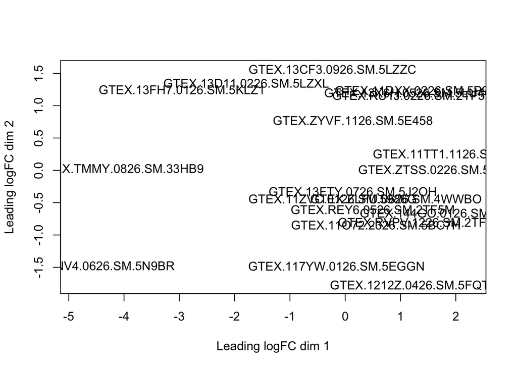

```r
plotMDS(d)
```

El siguiente paso es la ejecución del análisis diferencial con las funcionalidades que proporciona la librería *edgeR*. Aunque es recomendable usar las dispersiones que porporciona *tagwise* ya que son más específicas, no se han utilizado porque al usarlo en las tres comparaciones no se encontraban genes diferencialmente expresados comunes. Por esta razón se ha usado las dispersiones *common*.

```r
d_NIT_SFI <- estimateCommonDisp(d)
dtag_NIT_SFI <- estimateTagwiseDisp(d_NIT_SFI)
res.common_NIT_SFI  <- exactTest(d_NIT_SFI, pair=c("NIT", "SFI"), dispersion="common")
res.tagwise_NIT_SFI <- exactTest(dtag_NIT_SFI, pair=c("NIT", "SFI"), dispersion="tagwise")

# plotBCV(dtag_NIT_SFI, cex=0.4)

dec_NIT_SFI <- decideTestsDGE(res.common_NIT_SFI, p=0.001, adjust="BH")
dtag_NIT_SFI <- rownames(d_NIT_SFI)[as.logical(dec_NIT_SFI)]
d_NIT_SFI_df <- as.data.frame(dec_NIT_SFI)
d_NIT_SFI_df[, 2] <- rownames(res.common_NIT_SFI)
up_NIT_SFI <- d_NIT_SFI_df[which(d_NIT_SFI_df$`SFI-NIT` == 1),]
down_NIT_SFI <- d_NIT_SFI_df[which(d_NIT_SFI_df$`SFI-NIT` == -1),]
summary(dec_NIT_SFI)
```

```
       SFI-NIT
Down        52
NotSig   18002
Up         715
```

```r
genes_NIT_SFI <- c(up_NIT_SFI$V2, down_NIT_SFI$V2)
```

Por útimo, para calcular los genes diferencialmente expresados y saber cual de ellos están sobre-expresados e infra-expresados se emplea el test exacto de Fisher.

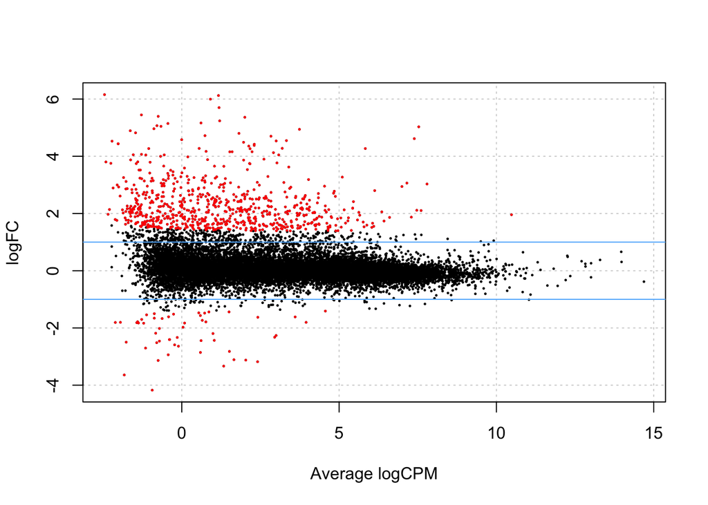

## Comparación NIT-ELI

El primer paso que se hace es el de crear un grupo con las infiltraciones de la comparación NIT y ELI seleccionando las muestras adecuadas del dataframe original. A continuación se aplica un refiltrado con la función *sweep*. El objetivo de hacer este refiltrado es que el gen tenga alguna presencia, para esto se va indicar que aparezca como mínimo 1 lectura por cada millón de veces que sea mapeado.

```r
comp_NIT_ELI <- cbind(normalize_samples[, 1:10], normalize_samples[, 21:30])


col_NIT_ELI <- rbind(target_NIT_10, target_ELI_10)
group_NIT_ELI <- factor(col_NIT_ELI$Group)

d <- calcNormFactors(DGEList(counts = comp_NIT_ELI, group=group_NIT_ELI))
m <- sweep(d$counts, 2, 1e6 / d$samples$lib.size, "*")
ridx_NIT_ELI <- rowSums(m>1) >= 2
```

En el siguiente gráfico se muestra el diagrama de como es el escalamiento multidimensional de las muestras.

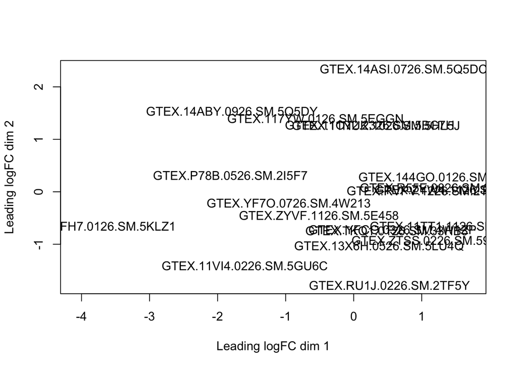

```r
plotMDS(d)
```

El siguiente paso es la ejecución del análisis diferencial con las funcionalidades que proporciona la librería *edgeR*. Aunque es recomendable usar las dispersiones que porporciona *tagwise* ya que son más específicas, no se han utilizado porque al usarlo en las tres comparaciones no se encontraban genes diferencialmente expresados comunes. Por esta razón se ha usado las dispersiones *common*.

```r
table(ridx_NIT_ELI)
```

```
ridx_NIT_ELI
FALSE  TRUE
28071 18231
```

```r
d <- d[ridx_NIT_ELI, ]
d_NIT_ELI <- estimateCommonDisp(d)
dtag_NIT_ELI <- estimateTagwiseDisp(d_NIT_ELI)
res.common_NIT_ELI  <- exactTest(d_NIT_ELI, pair=c("NIT", "ELI"), dispersion="common")
res.tagwise_NIT_ELI <- exactTest(dtag_NIT_ELI, pair=c("NIT", "ELI"), dispersion="tagwise")

# plotBCV(dtag_NIT_ELI, cex=0.4)

dec_NIT_ELI <- decideTestsDGE(res.common_NIT_ELI, p=0.001, adjust="BH")
dtag_NIT_ELI <- rownames(d_NIT_ELI)[as.logical(dec_NIT_ELI)]
d_NIT_ELI_df <- as.data.frame(dec_NIT_ELI)
d_NIT_ELI_df[,2] <- rownames(res.common_NIT_ELI)
up_NIT_ELI <- d_NIT_ELI_df[which(d_NIT_ELI_df$`ELI-NIT` == 1),]
down_NIT_ELI <- d_NIT_ELI_df[which(d_NIT_ELI_df$`ELI-NIT` == -1),]
summary(dec_NIT_ELI)
```

```
       ELI-NIT
Down       142
NotSig   17992
Up          97
```

```r
genes_NIT_ELI <- c(up_NIT_ELI$V2, down_NIT_ELI$V2)
```

Por útimo, para calcular los genes diferencialmente expresados y saber cual de ellos están sobre-expresados e infra-expresados se emplea el test exacto de Fisher.

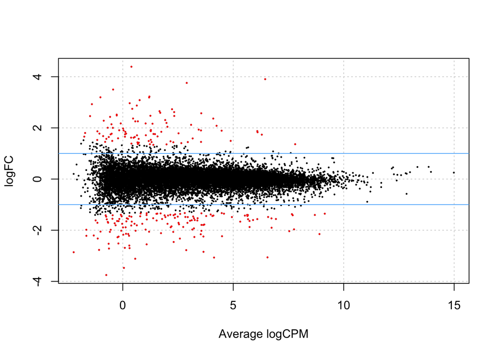

## Comparación SFI_ELI

El primer paso que se hace es el de crear un grupo con las infiltraciones de la comparación SFI y ELI seleccionando las muestras adecuadas del dataframe original. A continuación se aplica un refiltrado con la función *sweep*. El objetivo de hacer este refiltrado es que el gen tenga alguna presencia, para esto se va indicar que aparezca como mínimo 1 lectura por cada millón de veces que sea mapeado.

```r
comp_SFI_ELI <- normalize_samples[, 11:30]


col_SFI_ELI <- rbind(target_SFI_10, target_ELI_10)
group_SFI_ELI <- factor(col_SFI_ELI$Group)

d <- calcNormFactors(DGEList(counts = comp_SFI_ELI, group=group_SFI_ELI))
m <- sweep(d$counts, 2, 1e6 / d$samples$lib.size, "*")
ridx_SFI_ELI <- rowSums(m>1) >= 2
table(ridx_SFI_ELI)
```

```
ridx_SFI_ELI
FALSE  TRUE
27516 18786
```

```r
d <- d[ridx_SFI_ELI,]
```

En el siguiente gráfico se muestra el diagrama de como es el escalamiento multidimensional de las muestras.

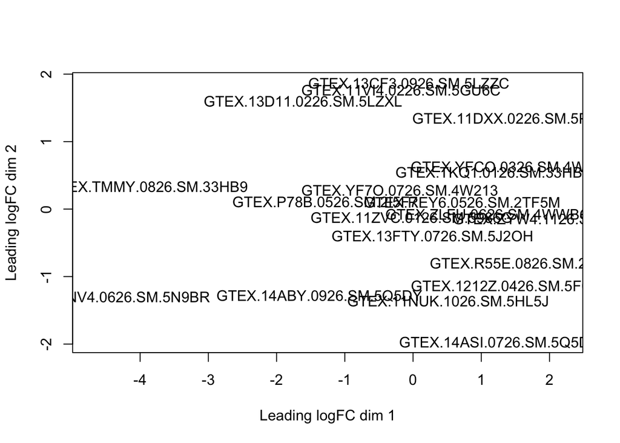

```r
plotMDS(d)
```

El siguiente paso es la ejecución del análisis diferencial con las funcionalidades que proporciona la librería *edgeR*. Aunque es recomendable usar las dispersiones que porporciona *tagwise* ya que son más específicas, no se han utilizado porque al usarlo en las tres comparaciones no se encontraban genes diferencialmente expresados comunes. Por esta razón se ha usado las dispersiones *common*.

```r
d_SFI_ELI <- estimateCommonDisp(d)
dtag_SFI_ELI <- estimateTagwiseDisp(d_SFI_ELI)
res.common_SFI_ELI  <- exactTest(d_SFI_ELI, pair=c("SFI", "ELI"), dispersion="common")
res.tagwise_SFI_ELI <- exactTest(dtag_SFI_ELI, pair=c("SFI", "ELI"), dispersion="tagwise")

# plotBCV(dtag_SFI_ELI, cex=0.4)

dec_SFI_ELI <- decideTestsDGE(res.common_SFI_ELI, p=0.001, adjust="BH")
dtag_SFI_ELI <- rownames(d_SFI_ELI)[as.logical(dec_SFI_ELI)]
d_SFI_ELI_df <- as.data.frame(dec_SFI_ELI)
d_SFI_ELI_df[,2] <- rownames(res.common_SFI_ELI)
up_SFI_ELI <- d_SFI_ELI_df[which(d_SFI_ELI_df$`ELI-SFI` == 1),]
down_SFI_ELI <- d_SFI_ELI_df[which(d_SFI_ELI_df$`ELI-SFI` == -1),]
summary(dec_SFI_ELI)
```

```
       ELI-SFI
Down       884
NotSig   17833
Up          69
```

```r
genes_SFI_ELI <- c(up_SFI_ELI$V2,down_SFI_ELI$V2)
```

Por útimo, para calcular los genes diferencialmente expresados y saber cual de ellos están sobre-expresados e infra-expresados se emplea el test exacto de Fisher.

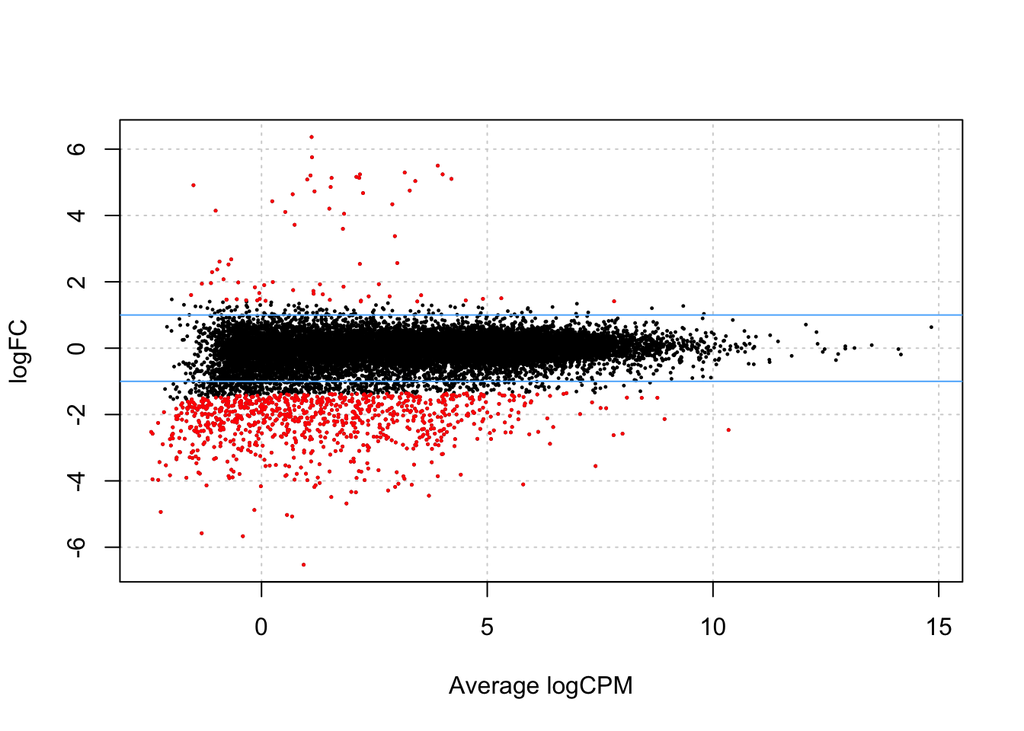

## Comparación conjunta

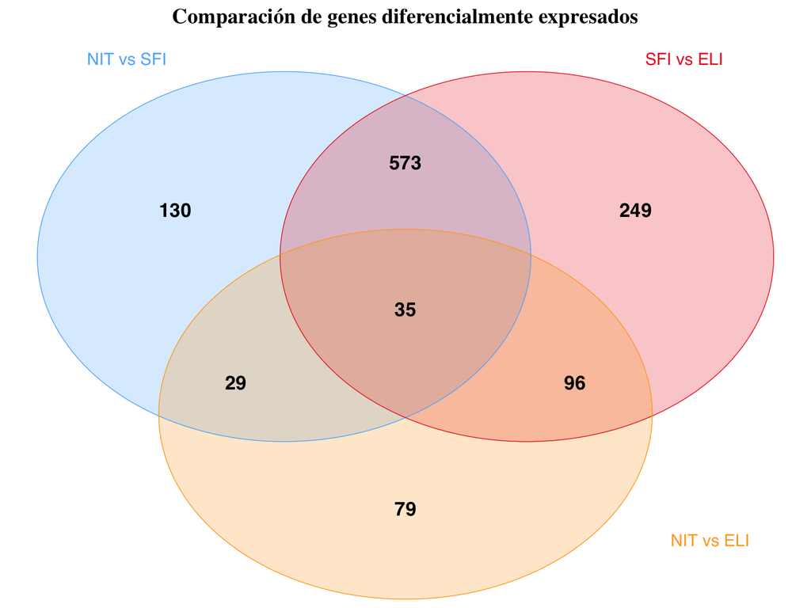

```r
commons <- intersect(intersect(genes_NIT_SFI, genes_NIT_ELI), genes_SFI_ELI)
# length(commons)
# up and down se calculan para comprobar después su anotación
up<-intersect(intersect(up_NIT_SFI$V2, up_NIT_ELI$V2), up_SFI_ELI$V2)
down<-intersect(intersect(down_NIT_SFI$V2, down_NIT_ELI$V2), down_SFI_ELI$V2)

vennDiagramColors <- c(BLUE_COLOR, RED_COLOR, YELLOW_COLOR)
vennPlot <- venn.diagram(x=list(genes_NIT_SFI, genes_SFI_ELI, genes_NIT_ELI),
                   category.names = c("NIT vs SFI", "SFI vs ELI", "NIT vs ELI"),
                   filename=NULL,
                   main="Comparación de genes diferencialmente expresados",
                   main.fontface="bold", main.cex=1.25,
                   col=vennDiagramColors, fill=vennDiagramColors,
                   fontfamily="sans", fontface="bold", cex=1.15,
                   cat.col=vennDiagramColors, cat.fontfamily="sans", cat.cex=1,
                   cat.default.pos="outer", cat.pos=c(-30, 30, 120),
                   cat.dist=c(0.055, 0.055, 0.085), rotation=1,
                   lwd=0.75, alpha=0.25)
grid.draw(vennPlot)
```

El gráfico está indicando que en la intersección existen 35 genes diferencialmente expresados.

## Anotación de los genes

La librería *biomaRt* es la que se ha empleado para la anotación de los genes diferencialmente expresados.

```r
mart <- useMart(biomart="ensembl", dataset="hsapiens_gene_ensembl")

genes_commons<-getBM(attributes=c("hgnc_symbol"),
                     filters="ensembl_gene_id_version",
                     values=commons, mart=mart)
genes_commons <- genes_commons[, 1]
# genes_commons
ups <- getBM(attributes=c("hgnc_symbol", "description"),
           filters="ensembl_gene_id_version",
           values=up, mart=mart)
# ups
downs <- getBM(attributes=c("hgnc_symbol","description"),
             filters="ensembl_gene_id_version",
             values=down, mart=mart)
# downs
```

```r
genes_commons
```

```
## [1] "PNLIP"       "IGLV1-47"    "IGLV7-43"    "IGLV3-19"    "IGLC6"
## [6] "IGHJ3"       "IGHV4OR15-8"
```

```r
ups
```

```
## [1] hgnc_symbol description
## <0 rows> (or 0-length row.names)
```

```r
down
```

```
## [1] "ENSG00000171195.6"
```

## Significación biológica

```r
total_genes <- getBM(attributes=c("hgnc_symbol", "go_id"),
                     filters="ensembl_gene_id_version",
                     values=rownames(samples), mart=mart)

#head(total_genes, 10)
tmp <- which(total_genes$go_id == "")
total_genes <- total_genes[-tmp, ]

# se necesita convertir en lista para poder calcular el objeto topGo
lista <- list()
for (i in unique(total_genes$hgnc_symbol)) {
  lista[[i]] = total_genes[which(total_genes$hgnc_symbol == i),]$go_id
}
# head(lista, 10)

gen <- names(lista)
comparative_gene <- factor(as.integer(gen %in% genes_commons))
```

```r
names(comparative_gene) <- gen

GO_data <- new("topGOdata", ontology="BP", allGenes=comparative_gene, annot=annFUN.gene2GO, gene2GO=lista)
```

```
Building most specific GOs .....
```

```
    ( 1510 GO terms found. )
```

```
Build GO DAG topology ..........
```

```
    ( 4409 GO terms and 10129 relations. )
```

```
Annotating nodes ...............
```

```
    ( 664 genes annotated to the GO terms. )
```

La prueba de *Fisher* se ha empleado para obtener las anotaciones GO asociadas que indica que son significativas.

```r
fisher_test = runTest(GO_data, algorithm="classic", statistic="fisher")
```

```r
fisher_test
```

```
Description:
Ontology: BP
'classic' algorithm with the 'fisher' test
4409 GO terms scored: 63 terms with p < 0.01
Annotation data:
    Annotated genes: 664
    Significant genes: 5
    Min. no. of genes annotated to a GO: 1
    Nontrivial nodes: 158
```

De las 4409 anotaciones de Go totales, 664 de 5 genes diferencialmente expresados fueron analizados. De todos esto, 63 obtienen un p valor inferior a 0.01.

# Conclusión

La mejor forma de obtener alguna interpretación biológica es usando un gráfico del enrequicimiento realizado en la significación biológica. El siguiente gráfico representa las anotaciones significativamente más importantes.

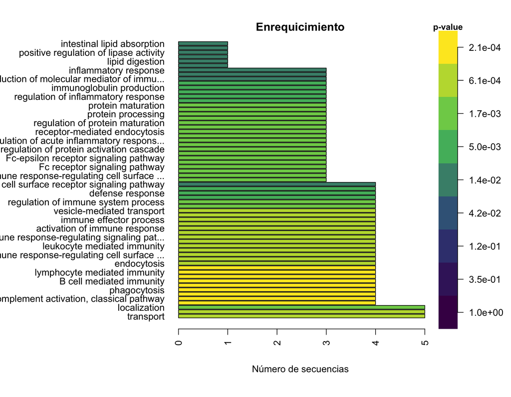

```r
nodes = sum(score(fisher_test) <= 0.01)
allRes = GenTable(GO_data, classicFisher=fisher_test, topNodes=nodes)
# head(allRes)

layout(t(1:2), widths=c(8, 1))
par(mar=c(4, 0.5, 0.7, 0.7), oma=c(2, 15, 2, 4), las=1)

rgb_pal = colorRampPalette(c("#fde725", "#55c667", "#39568c","#440154"))

p_value = as.numeric(gsub("<", "", allRes$classicFisher))
max_value = as.integer(max(-log(p_value))) + 1
min_value = 1
p_v_range = exp(-seq(max_value, 0, -1))
allRes$Color = rgb_pal(max_value) [cut(p_value, p_v_range)]

ord = order(allRes$Significant, decreasing = T)
barplot(allRes$Significant[ord], names.arg=allRes$Term[ord], las=2, horiz=T,
        col=allRes$Color[ord], xlab="Número de secuencias",
        main="Enrequicimiento")

image(0, seq(min_value, max_value), t(seq_along(seq(min_value, max_value))),
      col=rev(rgb_pal(max_value)), axes=F, ann=F)

p_v_label = formatC(exp(-seq(log(min_value), -log(min(p_value)), l=9)), format="e", digits=1)
axis(4, at=seq(min_value, max_value, length=9), labels=p_v_label)
title("p-value", cex.main=0.9)
```

Las 63 anotaciones más importantes se muestran a continuación:

```
 [1] "humoral immune response mediated by circ..."
 [2] "complement activation, classical pathway"
 [3] "complement activation"
 [4] "phagocytosis"
 [5] "immunoglobulin mediated immune response"
 [6] "B cell mediated immunity"
 [7] "protein activation cascade"
 [8] "lymphocyte mediated immunity"
 [9] "adaptive immune response based on somati..."
[10] "endocytosis"
[11] "immune response-activating cell surface ..."
[12] "immune response-regulating cell surface ..."
[13] "import into cell"
[14] "leukocyte mediated immunity"
[15] "immune response-activating signal transd..."
```

[output cut: 48 more lines]